# Tutorial 5

# Notes for exercises by Kaiyan Zheng

## Q1: Palindrome Integers

## Write the functions with the following headers:

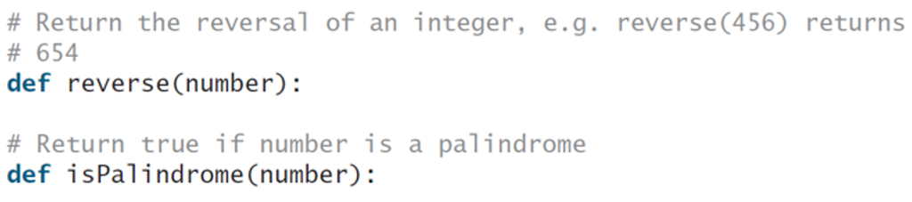

## Use the reverse function to implement isPalindrome. A number is a palindrome if its reversal is the same as itself. Write a test program that prompts the user to enter an integer and reports whether the integer is a palindrome.

```python
"""
Function to reverse a given number using numeric operators
Parameters:
  number (int): The integer to be reversed
Returns:
  int: The reversed integer
"""
def reverse(number):
    reverseNumber = ''  # Initialize an empty string to store the reversed number
    while number != 0:
        remainder = number % 10  # Get the last digit of the number
        reverseNumber += str(remainder)  # Append the digit to the reversed number as a string
        number //= 10  # Remove the last digit from the number
    reverseNumber = int(reverseNumber)  # Convert the reversed string back to an integer
    return reverseNumber

'''
Function to check if a number is a palindrome
Parameters:
  number (int): The integer to be checked for palindromicity
Returns:
  bool: True if the number is a palindrome, False otherwise
'''
def isPalindrome(number):
    if number == reverse(number):  # Check if the number is equal to its reverse
        return True
    else:
        return False

# Main function to take user input and determine if it's a palindrome
def main():
    num = eval(input("Enter an integer: "))  # Prompt the user for an integer input
    if isPalindrome(num):
        print("%d is a palindrome." % num)
    else:
        print("%d is not a palindrome." % num)

# Call the main function to start the program
if __name__ == "__main__":
    main()
```

```
Enter an integer: 34543
34543 is a palindrome.
```

## Q2: Palindromic primes

## A palindromic prime is a prime number that is also palindromic. For example, 131 is a prime and also a palindromic prime, as are 313 and 757. Write a program that displays the first 100 palindromic prime numbers. Display 10 numbers per line and align the numbers properly, as follow:

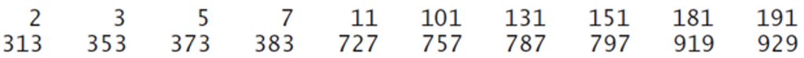

```python
"""
Define a function to obtain the reverse of a number.
Parameters:
    number (int): The integer to be reversed.
Returns:
    int: The reversed integer.
"""
def reverse(number):
    reverseNumber = ''  # Initialize an empty string to store the reversed number.
    while number != 0:
        reverseNumber += str(number % 10)  # Append the last digit of the number to the reversed number as a string.
        number //= 10  # Remove the last digit from the number.
    reverseNumber = int(reverseNumber)  # Convert the reversed string back to an integer.
    return reverseNumber

"""
Define a function to judge whether a number is a palindrome.
Parameters:
    number (int): The integer to be checked for palindromicity.
Returns:
    bool: True if the number is a palindrome, False otherwise.
"""
def isPalindrome(number):
    if number == reverse(number):  # Check if the number is equal to its reverse.
        return True
    else:
        return False

"""
Define a function to judge whether a number is a prime.
Parameters:
    number (int): The integer to be checked for primality.
Returns:
    bool: True if the number is prime, False otherwise.
"""
def isPrime(number):
    divisor = 2
    while divisor <= number / 2:
        if number % divisor == 0:
            return False
        else:
            divisor += 1
            continue
    return True

"""
Define a main function to display 100 numbers which are both palindromic and prime.
"""
def main():
    count = 0
    number = 2  # Begin from the smallest palindrome and prime, which is 2.
    while count < 100:
        if isPalindrome(number) and isPrime(number):
            print("%6d" % number, end='')  # Print the number with formatting.
            count += 1
            number += 1
        else:
            number += 1
            continue  # Move to the next number if it does not meet the criteria.
        if count % 10 == 0:  # Change line after every 10 numbers.
            print()

# Call the main function to start the program
if __name__ == "__main__":
    main()
```

```
     2     3     5     7    11   101   131   151   181   191
   313   353   373   383   727   757   787   797   919   929
 10301 10501 10601 11311 11411 12421 12721 12821 13331 13831
 13931 14341 14741 15451 15551 16061 16361 16561 16661 17471
 17971 18181 18481 19391 19891 19991 30103 30203 30403 30703
 30803 31013 31513 32323 32423 33533 34543 34843 35053 35153
 35353 35753 36263 36563 37273 37573 38083 38183 38783 39293
 70207 70507 70607 71317 71917 72227 72727 73037 73237 73637
 74047 74747 75557 76367 76667 77377 77477 77977 78487 78787
 78887 79397 79697 79997 90709 91019 93139 93239 93739 94049
```

## Q3: Mytriangle module

## Create a module named MyTriangle that contains the following two functions:

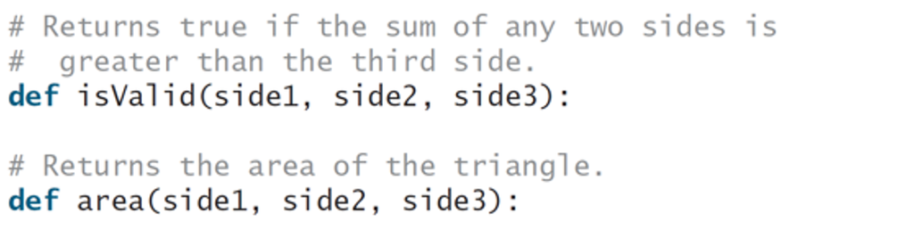

## Write a test program that reads three sides for a triangle and computes the area if the input is valid. Otherwise, it displays that the input is invalid.

### Here is the myTraingle module, which I have put it in the same folder of this notebook.

```python
#Define a function to check whether the values of three sides is valid
def isValid(side1,side2,side3):
    return (side1+side2>side3) and (side1+side3>side2) and (side2+side3>side1)

#Calculate the area of a triangle given the values of its three sides
def area(side1,side2,side3):
    costheta=(side1**2+side2**2-side3**2)/(2*side1*side2)
    sintheta=(1-costheta**2)**0.5
    return 0.5*side1*side2*sintheta
```

### Sample answer of the question:

```python
from MyTriangle import *  # Import all functions in the module MyTriangle

# Define a main function to input three sides of a triangle and judge whether it is a valid triangle
def main():
    # Prompt the user to enter the three sides of a triangle
    a, b, c = eval(input("Enter the three sides of a triangle: "))

    # Check if the input sides form a valid triangle
    if isValid(a, b, c):
        # Calculate and print the area of the triangle with formatting
        print("The area of the triangle is %.2f." % area(a, b, c))
    else:
        # Print an error message if the input is invalid
        print("The input is invalid.")

# Call the main function to start the program
if __name__ == "__main__":
    main()
```

```
Enter the three sides of a triangle: 3,4,5
The area of the triangle is 6.00.
```

## Q4: Yang Hui's Triangle

## Yang Hui’s Triangle(Pascal’s Triangle) is a triangle with numbers where each of them in one line equals to the sum of the two neighbor numbers in previous line. Equivalently, it is a triangular array of the binomial coefficients. Write a program to print Yang Hui’s Triangle with given number of lines.

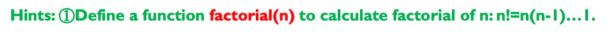

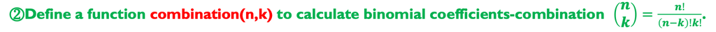

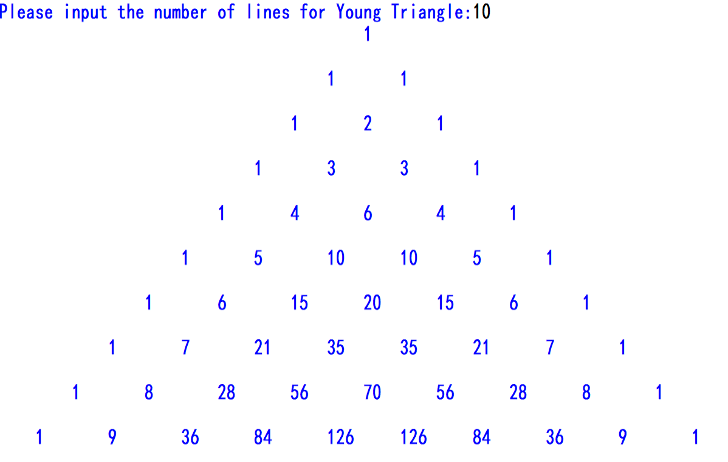

```python
# Function to calculate the factorial of a given number n
# Parameters:
#   n (int): The number for which the factorial is calculated
# Returns:
#   int: The factorial of n
def factorial(n):
    result = 1
    for i in range(n):
        result *= (i + 1)
    return result

# Function to calculate the combination C(n, k) (number of ways to select k elements from n)
# Parameters:
#   n (int): Total number of elements
#   k (int): Number of elements to be selected
# Returns:
#   int: The combination C(n, k)
def Combinationnk(n, k):
    result = factorial(n) / (factorial(k) * factorial(n - k))
    return result

# Main program to print Yang Hui's Triangle
N = eval(input('Please input the number of lines for Yang Hui Triangle: '))
for i in range(N):
    # Print spaces before printing the numbers
    print(('%-4s' * (N - i)) % ((' ',) * (N - i)), end='')

    # Print elements for the triangle, with one space between each
    for k in range(i + 1):
        print('%-4d%-4s' % (Combinationnk(i, k), ' '), end='')

    # Print spaces on the right of each line, after the numbers
    print(('%-4s' * (N - i)) % ((' ',) * (N - i)))
```

```
Please input the number of lines for Yang Hui Triangle: 6
                        1
                    1       1
                1       2       1
            1       3       3       1
        1       4       6       4       1
    1       5       10      10      5       1
```

## An example of global variables

```python
# Initialize global variables 'a' and 'b'
a = 1
b = 2

# Function Add1 calculates the sum of two numbers and prints the result
# Parameters:
#   a (int): The first number
#   b (int): The second number
def Add1(a, b):
    total = a + b
    print('Sum in Add1 function is %d' % total)
    print('Within Add1 Function: a is %d, b is %d' % (a, b))

# Function Add2 calculates the sum of global variables 'a' and 'b' and prints the result
def Add2():
    global a, b
    total = a + b
    print('Sum in Add2 function is %d' % total)
    print('Within Add2 Function: a is %d, b is %d' % (a, b))

# Function Add3 calculates the sum of two numbers and updates global variables 'a' and 'b'
# Parameters:
#   c (int): The new value for 'a'
#   d (int): The new value for 'b'
def Add3(c, d):
    global a, b
    a = c
    b = d
    total = a + b
    print('Sum in Add3 function is %d' % total)
    print('Within Add3 Function: a is %d, b is %d' % (a, b))

# Main program to demonstrate the usage of the functions
def main():
    # Call Add1 function with parameters 3 and 4
    Add1(3, 4)
    print('After calling Add1 function: a is %d, b is %d\n' % (a, b))

    # Call Add2 function, which uses global variables 'a' and 'b'
    Add2()
    print('After calling Add2 function: a is %d, b is %d\n' % (a, b))

    # Call Add3 function, which updates global variables 'a' and 'b' with new values 5 and 6
    Add3(5, 6)
    print('After calling Add3 function: a is %d, b is %d\n' % (a, b))

if __name__ == "__main__":
    main()
```

```
Sum in Add1 function is 7
Within Add1 Function: a is 3, b is 4
After calling Add1 function: a is 1, b is 2

Sum in Add2 function is 3
Within Add2 Function: a is 1, b is 2
After calling Add2 function: a is 1, b is 2

Sum in Add3 function is 11
Within Add3 Function: a is 5, b is 6
After calling Add3 function: a is 5, b is 6
```

# Bonus content: 布尔运算符

In python, the boolean operators “and” and “or” are short circuiting.  
That is, when we evaluate the expression 'x and y', we first evaluate x. If x evaluates to False, then the entire expression cannot evaluate to True, and so we do not evaluate y. Python中的布尔运算符包括 "and" 和 "or"，它们是短路运算的。这意味着它们在评估表达式时会根据需要跳过部分计算，以提高执行效率。

## "and" 运算符

当使用 "and" 运算符时，首先会评估第一个条件（左操作数）。如果第一个条件为FALSE，整个表达式将被判定为FALSE，而不会继续评估第二个条件（右操作数）。只有当第一个条件为TRUE时，才会继续评估第二个条件。

例如：

[output not shown]

## "or" 运算符

Similarly, when using the "or" operator, the first condition is evaluated first. If the first condition is TRUE, the entire expression is judged to be TRUE and the second condition is not evaluated. The second condition is evaluated only if the first condition is FALSE.

类似地，当使用 "or" 运算符时，首先会评估第一个条件。如果第一个条件为TRUE，整个表达式将被判定为TRUE，而不会继续评估第二个条件。只有当第一个条件为FALSE时，才会继续评估第二个条件。

例如：

```
x = True
y = False
result = x or y  # result 将为 True，因为 y 不会被评估
```